# Práctica Sesión 9 - 10: Factor Investing

Asignatura: Gestión de Activos y Carteras

- Marina Ortín
- Alvaro Muñoz
- Mayra Goicochea

En el presente informe, se realiza la construcción de una cartera de activos según las estrategias de predicción de Rendimientos basados en el estudio del Risk Premia como: Value, Low Beta, Size, Momentum y Quality.

**Librerías**

```python
import pandas as pd
import numpy as np
import matplotlib.pyplot as plt
import seaborn as sns
import scipy.optimize as sco
import scipy.stats as scs
from datetime import datetime
plt.style.use('fivethirtyeight')
np.random.seed(777)
import statsmodels.api as sm
from statsmodels import regression

%matplotlib inline
%config InlineBackend.figure_format = 'retina'
import warnings
plt.style.use('seaborn')
warnings.simplefilter(action='ignore', category=FutureWarning)
```

## Extraer datos relacionados con activos

Se extraen los datos de los archivos `data.csv`, `dataset_Index.csv` y `data_assets.csv`, dado que son datos generados desde bloomberg, y se guardan en un dataframe:

```python
data_df = pd.read_csv("./source/data.csv", index_col='Unnamed: 0',float_precision='high')
data_df.head()
```

|  | Name | Price | Currency | FX Chang | Sector | Country | Rentab 1Y | Volat 30d | Volat 360d | EV_TO_T12M_EBITDA | EQY_DVD_YLD_12M | NET_OPERATING_ASSETS | RETURN_ON_INV_CAPITAL | EQY_BETA | EQY_REC_CONS | TOT_ANALYST_REC | TOT_BUY_REC | TOT_SELL_REC | TWITTER_SENTIMENT | NEWS_SENTIMENT |
| --- | --- | --- | --- | --- | --- | --- | --- | --- | --- | --- | --- | --- | --- | --- | --- | --- | --- | --- | --- | --- |
| NESN SW Equity | NESTLE SA-REG | 101.32 | CHF | 0.9402 | Food | SWITZERLAND | 0.018599 | 0.237874 | 0.199545 | 0.166487 | 0.026648 | 79763.0000 | 0.138397 | 0.812534 | 3.851852 | 27 | 13 | 1 | 0.0 | 0.382784 |
| ROG SW Equity | ROCHE HOLDING AG-GENUSSCHEIN | 332.10 | CHF | 0.9402 | Pharmaceuticals | SWITZERLAND | 0.221180 | 0.256552 | 0.224647 | 0.128229 | 0.027100 | 39591.0000 | 0.279033 | 1.031748 | 3.687500 | 32 | 16 | 5 | 0.0 | 0.034268 |
| NOVN SW Equity | NOVARTIS AG-REG | 81.18 | CHF | 0.9402 | Pharmaceuticals | SWITZERLAND | -0.082919 | 0.259980 | 0.231213 | 0.150534 | 0.036339 | 73355.0000 | 0.086807 | 1.073373 | 3.827586 | 29 | 16 | 4 | 0.0 | 0.261707 |
| BATS LN Equity | BRITISH AMERICAN TOBACCO PLC | 3275.00 | GBp | 1.1150 | Agriculture | BRITAIN | 0.097336 | 0.341078 | 0.326400 | 0.110997 | 0.062550 | 106877.0000 | 0.051704 | 1.123634 | 4.473684 | 19 | 14 | 0 | 0.0 | 0.112235 |
| FP FP Equity | TOTAL SA | 34.04 | EUR | 1.0000 | Oil&Gas | FRANCE | -0.288610 | 0.523668 | 0.397920 | 0.051470 | 0.077556 | 131091.8158 | 0.041398 | 1.290288 | 3.466667 | 30 | 10 | 3 | 0.0 | 0.000000 |

### Precios de las Acciones

```python
assets_df = pd.read_csv("./source/data_assets.csv", index_col='Unnamed: 0')
assets_df.index = [datetime.strptime(str(i), '%d/%m/%Y') for i in assets_df.index.values]
ass_cols = assets_df.columns.to_list()
assets_df.info()
```

```
<class 'pandas.core.frame.DataFrame'>
DatetimeIndex: 2109 entries, 2012-04-18 to 2020-05-18
Columns: 174 entries, NESN SW Equity to PFE UN Equity
dtypes: float64(173), int64(1)
memory usage: 2.8 MB
```

```python
for col in assets_df.columns:
    assets_df[col] = assets_df[col].pct_change()
assets_df.head()
```

|  | NESN SW Equity | ROG SW Equity | NOVN SW Equity | BATS LN Equity | FP FP Equity | RDSA LN Equity | SAN FP Equity | SIE GY Equity | RDSB LN Equity | BAYN GY Equity | ... | AXP UN Equity | WMT UN Equity | MSFT UW Equity | MRK UN Equity | NKE UN Equity | VZ UN Equity | KO UN Equity | INTC UW Equity | CSCO UW Equity | PFE UN Equity |
| --- | --- | --- | --- | --- | --- | --- | --- | --- | --- | --- | --- | --- | --- | --- | --- | --- | --- | --- | --- | --- | --- |
| 2012-04-18 | NaN | NaN | NaN | NaN | NaN | NaN | NaN | NaN | NaN | NaN | ... | NaN | NaN | NaN | NaN | NaN | NaN | NaN | NaN | NaN | NaN |
| 2012-04-19 | 0.009709 | 0.009208 | 0.004909 | 0.010183 | -0.026393 | -0.014624 | -0.008356 | -0.017987 | -0.011322 | -0.002476 | ... | -0.008098 | -0.004995 | -0.003532 | -0.001042 | -0.008593 | 0.013011 | -0.004719 | -0.008948 | -0.006979 | -0.005791 |
| 2012-04-20 | -0.001748 | 0.026156 | 0.004885 | 0.006203 | 0.003165 | 0.006596 | 0.015956 | 0.011729 | 0.008933 | 0.025365 | ... | -0.002084 | 0.011336 | 0.044795 | 0.009645 | 0.010583 | 0.015203 | 0.004199 | -0.003250 | -0.000502 | 0.010753 |
| 2012-04-23 | -0.028021 | -0.014819 | -0.005745 | -0.009402 | -0.024417 | -0.012403 | -0.019411 | -0.025186 | -0.010443 | -0.043915 | ... | -0.002263 | -0.046597 | -0.009254 | -0.011877 | -0.009208 | -0.004131 | -0.005936 | -0.005435 | -0.011552 | -0.007979 |
| 2012-04-24 | 0.000000 | 0.001805 | -0.014889 | -0.017582 | 0.009843 | 0.009479 | 0.018355 | 0.013210 | 0.009635 | 0.014025 | ... | 0.005408 | -0.029728 | -0.006227 | 0.000000 | -0.027335 | 0.024112 | 0.005835 | -0.005100 | -0.013211 | 0.011171 |

5 rows × 174 columns

### Indices Referenciales

```python
index_df = pd.read_csv("./source/data_index.csv", index_col='Unnamed: 0')
index_df.index = [datetime.strptime(str(i), '%d/%m/%Y') for i in index_df.index.values]
index_df=index_df[['MXWO','MXWOSC']]
index_df.head()
```

|  | MXWO | MXWOSC |
| --- | --- | --- |
| 2012-04-18 | 1283.87 | 234.16 |
| 2012-04-19 | 1277.72 | 233.23 |
| 2012-04-20 | 1281.71 | 234.13 |
| 2012-04-23 | 1264.21 | 230.65 |
| 2012-04-24 | 1271.80 | 231.67 |

```python
index_df['MXWO_Return']=index_df['MXWO'].pct_change()
index_df['MXWOSC_Return']=index_df['MXWOSC'].pct_change()
```

```python
val = []
val.append(100)
for i in range(1,index_df.shape[0]):
    val.append(val[i-1]*(1+index_df['MXWO_Return'].iloc[i]))
index_df['MXWO_Ix'] = val
val = []
val.append(100)
for i in range(1,index_df.shape[0]):
    val.append(val[i-1]*(1+index_df['MXWOSC_Return'].iloc[i]))  ##Dow Jones
index_df['MXWOSC_Ix'] = val
```

```python
index_df[['MXWO_Ix','MXWOSC_Ix']].head().style.background_gradient(cmap='YlGnBu')
```

|  | MXWO_Ix | MXWOSC_Ix |
| --- | --- | --- |
| 2012-04-18 00:00:00 | 100 | 100 |
| 2012-04-19 00:00:00 | 99.521 | 99.6028 |
| 2012-04-20 00:00:00 | 99.8318 | 99.9872 |
| 2012-04-23 00:00:00 | 98.4687 | 98.501 |
| 2012-04-24 00:00:00 | 99.0599 | 98.9366 |

## Modelos de predicción de rendimientos - Risk Premia

### Modelo Risk Premia Value

- Se beneficia de la convergencia de precios entre activos infravalorados y sobrevalorados. los el valor relativo de una seguridad es evaluado por un medida económica (relación price to book, PPP para las monedas ...).
- Implementación: compra de valores infravalorados, venta de valores sobrevalorados.
- Tipos de activos: Equities, rates, credit, FX, commodities.

```python
val_df = data_df[['EV_TO_T12M_EBITDA','EQY_DVD_YLD_12M']]
val_df.columns = ['EBITDA_EV_12M', 'EQY_DVD_12M']
val_df.head()
```

|  | EBITDA_EV_12M | EQY_DVD_12M |
| --- | --- | --- |
| NESN SW Equity | 0.166487 | 0.026648 |
| ROG SW Equity | 0.128229 | 0.027100 |
| NOVN SW Equity | 0.150534 | 0.036339 |
| BATS LN Equity | 0.110997 | 0.062550 |
| FP FP Equity | 0.051470 | 0.077556 |

```python
val_df = val_df.rank(axis=0,method='first',ascending=False).astype(int)
longWeight_1 = 1
shortWeight_1 = -1
longWeight_2 = 0.5
shortWeight_2 = -0.5
longRank = 35
shortRank = 35
n = val_df.iloc[:,0].max()
f = n-shortRank
val_df.head(10).style.background_gradient(cmap='YlGnBu')
```

|  | EBITDA_EV_12M | EQY_DVD_12M |
| --- | --- | --- |
| NESN SW Equity | 26 | 101 |
| ROG SW Equity | 55 | 98 |
| NOVN SW Equity | 35 | 69 |
| BATS LN Equity | 78 | 27 |
| FP FP Equity | 160 | 16 |
| RDSA LN Equity | 163 | 9 |
| SAN FP Equity | 15 | 67 |
| SIE GY Equity | 90 | 63 |
| RDSB LN Equity | 164 | 5 |
| BAYN GY Equity | 114 | 48 |

```python
val_df['EBITDA_EV_12M'] = np.where(val_df['EBITDA_EV_12M']<=longRank,longWeight_1/longRank,
                        np.where(val_df['EBITDA_EV_12M']>f,shortWeight_1/shortRank,0))
val_df['EQY_DVD_12M'] = np.where(val_df['EQY_DVD_12M']<=longRank,longWeight_2/longRank,
                        np.where(val_df['EQY_DVD_12M']>f,shortWeight_2/shortRank,0))
```

```python
val_df.head(10).style.background_gradient(cmap='YlGnBu')
```

|  | EBITDA_EV_12M | EQY_DVD_12M |
| --- | --- | --- |
| NESN SW Equity | 0.0285714 | 0 |
| ROG SW Equity | 0 | 0 |
| NOVN SW Equity | 0.0285714 | 0 |
| BATS LN Equity | 0 | 0.0142857 |
| FP FP Equity | -0.0285714 | 0.0142857 |
| RDSA LN Equity | -0.0285714 | 0.0142857 |
| SAN FP Equity | 0.0285714 | 0 |
| SIE GY Equity | 0 | 0 |
| RDSB LN Equity | -0.0285714 | 0.0142857 |
| BAYN GY Equity | 0 | 0 |

```python
val_df['Total'] = val_df.sum(1)
val_df.head(10).style.background_gradient(cmap='YlGnBu')
```

|  | EBITDA_EV_12M | EQY_DVD_12M | Total |
| --- | --- | --- | --- |
| NESN SW Equity | 0.0285714 | 0 | 0.0285714 |
| ROG SW Equity | 0 | 0 | 0 |
| NOVN SW Equity | 0.0285714 | 0 | 0.0285714 |
| BATS LN Equity | 0 | 0.0142857 | 0.0142857 |
| FP FP Equity | -0.0285714 | 0.0142857 | -0.0142857 |
| RDSA LN Equity | -0.0285714 | 0.0142857 | -0.0142857 |
| SAN FP Equity | 0.0285714 | 0 | 0.0285714 |
| SIE GY Equity | 0 | 0 | 0 |
| RDSB LN Equity | -0.0285714 | 0.0142857 | -0.0142857 |
| BAYN GY Equity | 0 | 0 | 0 |

```python
#Resultado
w_assets = val_df['Total'].to_list()
w_assets=dict(zip(assets_df[ass_cols].columns.to_list(),w_assets))
```

```python
df=assets_df[ass_cols]
assets_df['Value'] = df.assign(**w_assets).mul(df).sum(1)
```

```python
val = []
val.append(100)
for i in range(1,assets_df.shape[0]):
    val.append(val[i-1]*(1+assets_df['Value'].iloc[i]))
assets_df['Value_Ix'] = val
```

```python
assets_df[['Value','Value_Ix']].head().style.background_gradient(cmap='YlGnBu')
```

|  | Value | Value_Ix |
| --- | --- | --- |
| 2012-04-18 00:00:00 | 0 | 100 |
| 2012-04-19 00:00:00 | 0.0127191 | 101.272 |
| 2012-04-20 00:00:00 | 0.00415702 | 101.693 |
| 2012-04-23 00:00:00 | 0.00847159 | 102.554 |
| 2012-04-24 00:00:00 | -0.000641423 | 102.489 |

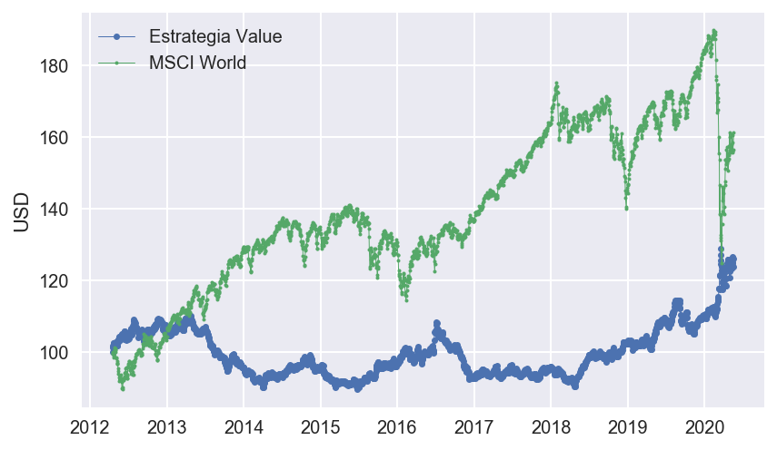

```python
fig, ax = plt.subplots()
ax.plot(assets_df['Value_Ix'],
        marker='.', linestyle='-', linewidth=0.5, label='Estrategia Value')
ax.plot(index_df['MXWO_Ix'],
        marker='o', markersize=2, linestyle='-',linewidth=0.5, label='MSCI World')
ax.set_ylabel('USD')
ax.legend();
```

### Estrategia Risk Premia Momentum

- Basada en un comportamiento sesgo: la demanda de valores con el mejor rendimiento reciente tiende a ser mayor que la demanda de valores con rendimiento más débil
- Implementación: Posiciones largas en acciones con mejor rendimiento, posiciones cortas en las de menos rendimiento.
- Activos: Equities, rates, credit, FX, commodities.

```python
mom_df = data_df[['Rentab 1Y']]
mom_df.head()
```

|  | Rentab 1Y |
| --- | --- |
| NESN SW Equity | 0.018599 |
| ROG SW Equity | 0.221180 |
| NOVN SW Equity | -0.082919 |
| BATS LN Equity | 0.097336 |
| FP FP Equity | -0.288610 |

```python
mom_df = mom_df.apply(lambda x: 10000000*x).astype(float).rank(axis=0,method='first',ascending=False).astype(int)
longWeight = 1
shortWeight = -1
longRank = 35
shortRank = 35
n = mom_df.iloc[:,0].max()
f = n-shortRank
mom_df.head(10).style.background_gradient(cmap='YlGnBu')
```

|  | Rentab 1Y |
| --- | --- |
| NESN SW Equity | 60 |
| ROG SW Equity | 18 |
| NOVN SW Equity | 89 |
| BATS LN Equity | 43 |
| FP FP Equity | 145 |
| RDSA LN Equity | 166 |
| SAN FP Equity | 30 |
| SIE GY Equity | 76 |
| RDSB LN Equity | 170 |
| BAYN GY Equity | 33 |

```python
for col in mom_df.columns:
    mom_df[col] = np.where(mom_df[col]<=longRank,longWeight/longRank,
                           np.where(mom_df[col]>f,shortWeight/shortRank,0))
```

```python
mom_df.head(10).style.background_gradient(cmap='YlGnBu')
```

|  | Rentab 1Y |
| --- | --- |
| NESN SW Equity | 0 |
| ROG SW Equity | 0.0285714 |
| NOVN SW Equity | 0 |
| BATS LN Equity | 0 |
| FP FP Equity | -0.0285714 |
| RDSA LN Equity | -0.0285714 |
| SAN FP Equity | 0.0285714 |
| SIE GY Equity | 0 |
| RDSB LN Equity | -0.0285714 |
| BAYN GY Equity | 0.0285714 |

```python
#Resultado
w_assets = mom_df['Rentab 1Y'].to_list()
w_assets=dict(zip(assets_df[ass_cols].columns.to_list(),w_assets))
```

```python
df =assets_df[ass_cols]
assets_df['Momentum'] = df.assign(**w_assets).mul(df).sum(1)
assets_df[['Momentum']].head().style.background_gradient(cmap='YlGnBu')
```

|  | Momentum |
| --- | --- |
| 2012-04-18 00:00:00 | 0 |
| 2012-04-19 00:00:00 | 0.00765891 |
| 2012-04-20 00:00:00 | 0.0025338 |
| 2012-04-23 00:00:00 | 0.000571509 |
| 2012-04-24 00:00:00 | -0.00673107 |

```python
val = []
val.append(100)
for i in range(1,assets_df.shape[0]):
    val.append(val[i-1]*(1+assets_df['Momentum'].iloc[i]))
assets_df['Momentum_Ix'] = val
```

```python
assets_df[['Momentum','Momentum_Ix']].head().style.background_gradient(cmap='YlGnBu')
```

|  | Momentum | Momentum_Ix |
| --- | --- | --- |
| 2012-04-18 00:00:00 | 0 | 100 |
| 2012-04-19 00:00:00 | 0.00765891 | 100.766 |
| 2012-04-20 00:00:00 | 0.0025338 | 101.021 |
| 2012-04-23 00:00:00 | 0.000571509 | 101.079 |
| 2012-04-24 00:00:00 | -0.00673107 | 100.399 |

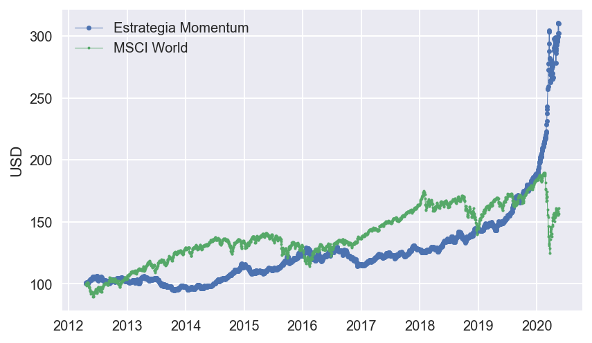

```python
fig, ax = plt.subplots()
ax.plot(assets_df['Momentum_Ix'],
marker='.', linestyle='-', linewidth=0.5, label='Estrategia Momentum')
ax.plot(index_df['MXWO_Ix'],
marker='o', markersize=2, linestyle='-',linewidth=0.5, label='MSCI World')
ax.set_ylabel('USD')
ax.legend();
```

### Estrategia Risk Premia Quality

- Se beneficia del rendimiento superior de las empresas que muestran una calidad superior, en términos de rentabilidad, distribución de dividendos, calidad de crédito, gobernanza ...
- Implementación:posiciones largas en acciones con alta calidad y posiciones cortas en acciones con baja calidad.
- Tipos de activos: equities

```python
qual_df = data_df[['NET_OPERATING_ASSETS','RETURN_ON_INV_CAPITAL']]
qual_df.head()
```

|  | NET_OPERATING_ASSETS | RETURN_ON_INV_CAPITAL |
| --- | --- | --- |
| NESN SW Equity | 79763.0000 | 0.138397 |
| ROG SW Equity | 39591.0000 | 0.279033 |
| NOVN SW Equity | 73355.0000 | 0.086807 |
| BATS LN Equity | 106877.0000 | 0.051704 |
| FP FP Equity | 131091.8158 | 0.041398 |

```python
qual_df = qual_df.rank(axis=0,method='first',ascending=False).astype(int)
longWeight_1 = 0    #Peso Largo en primer indicador
shortWeight_1 = 0   #Peso Corto en primer indicador
longWeight_2 = 1    #Peso Largo en segundo indicador
shortWeight_2 = -1  #Peso Corto en segundo indicador
longRank = 35
shortRank = 35
n = qual_df.iloc[:,0].max()
f = n-longRank
qual_df.head(10).style.background_gradient(cmap='YlGnBu')
```

|  | NET_OPERATING_ASSETS | RETURN_ON_INV_CAPITAL |
| --- | --- | --- |
| NESN SW Equity | 36 | 37 |
| ROG SW Equity | 72 | 6 |
| NOVN SW Equity | 42 | 70 |
| BATS LN Equity | 24 | 110 |
| FP FP Equity | 19 | 124 |
| RDSA LN Equity | 3 | 133 |
| SAN FP Equity | 40 | 126 |
| SIE GY Equity | 44 | 113 |
| RDSB LN Equity | 4 | 134 |
| BAYN GY Equity | 34 | 128 |

```python
qual_df['NET_OPERATING_ASSETS'] = np.where(qual_df['NET_OPERATING_ASSETS']<=longRank,longWeight_1/longRank,
                        np.where(qual_df['NET_OPERATING_ASSETS']>f,shortWeight_1/shortRank,0))
qual_df['RETURN_ON_INV_CAPITAL'] = np.where(qual_df['RETURN_ON_INV_CAPITAL']<=longRank,longWeight_2/longRank,
                        np.where(qual_df['RETURN_ON_INV_CAPITAL']>f,shortWeight_2/shortRank,0))
```

```python
qual_df.head(10).style.background_gradient(cmap='YlGnBu')
```

|  | NET_OPERATING_ASSETS | RETURN_ON_INV_CAPITAL |
| --- | --- | --- |
| NESN SW Equity | 0 | 0 |
| ROG SW Equity | 0 | 0.0285714 |
| NOVN SW Equity | 0 | 0 |
| BATS LN Equity | 0 | 0 |
| FP FP Equity | 0 | 0 |
| RDSA LN Equity | 0 | 0 |
| SAN FP Equity | 0 | 0 |
| SIE GY Equity | 0 | 0 |
| RDSB LN Equity | 0 | 0 |
| BAYN GY Equity | 0 | 0 |

```python
qual_df['Total'] = qual_df.sum(1)
qual_df.head(10).style.background_gradient(cmap='YlGnBu')
```

|  | NET_OPERATING_ASSETS | RETURN_ON_INV_CAPITAL | Total |
| --- | --- | --- | --- |
| NESN SW Equity | 0 | 0 | 0 |
| ROG SW Equity | 0 | 0.0285714 | 0.0285714 |
| NOVN SW Equity | 0 | 0 | 0 |
| BATS LN Equity | 0 | 0 | 0 |
| FP FP Equity | 0 | 0 | 0 |
| RDSA LN Equity | 0 | 0 | 0 |
| SAN FP Equity | 0 | 0 | 0 |
| SIE GY Equity | 0 | 0 | 0 |
| RDSB LN Equity | 0 | 0 | 0 |
| BAYN GY Equity | 0 | 0 | 0 |

```python
#Resultado
w_assets = qual_df['Total'].to_list()
w_assets=dict(zip(assets_df[ass_cols].columns.to_list(),w_assets))
```

```python
df =assets_df[ass_cols]
assets_df['Quality'] = df.assign(**w_assets).mul(df).sum(1)
```

```python
val = []
val.append(100)
for i in range(1,assets_df.shape[0]):
    val.append(val[i-1]*(1+assets_df['Quality'].iloc[i]))
assets_df['Quality_Ix'] = val
```

```python
assets_df[['Quality','Quality_Ix']].head().style.background_gradient(cmap='YlGnBu')
```

|  | Quality | Quality_Ix |
| --- | --- | --- |
| 2012-04-18 00:00:00 | 0 | 100 |
| 2012-04-19 00:00:00 | 0.00792395 | 100.792 |
| 2012-04-20 00:00:00 | -0.000671276 | 100.725 |
| 2012-04-23 00:00:00 | 0.0140536 | 102.14 |
| 2012-04-24 00:00:00 | -0.0131587 | 100.796 |

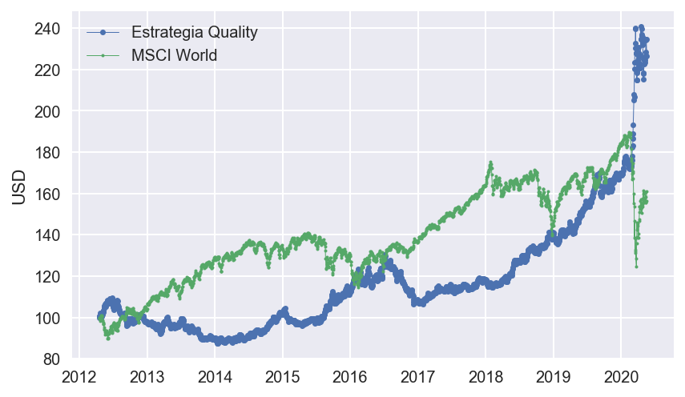

```python
fig, ax = plt.subplots()
ax.plot(assets_df['Quality_Ix'],
marker='.', linestyle='-', linewidth=0.5, label='Estrategia Quality')
ax.plot(index_df['MXWO_Ix'],
marker='o', markersize=2, linestyle='-',linewidth=0.5, label='MSCI World')
ax.set_ylabel('USD')
ax.legend();
```

### Estrategia Risk Premia Low Beta

- Los inversores que no pueden usar el apalancamiento están obligados a asignar sus activos de manera no óptima, sobreasignando a acciones de mayor riesgo. Esto genera un anomalía del mercado que, en general, es beneficioso para los valores menos riesgosos (menos susceptibles a correcciones de mercado).
- Implementación: Posiciones largas en activos menos arriesgados y posiciones cortas en las acciones de mayor riesgo.
- Tipos de activos: Equities, rates, credit, FX, commodities.

```python
beta_df = data_df[['EQY_BETA']]
beta_df.head().style.background_gradient(cmap='YlGnBu')
```

|  | EQY_BETA |
| --- | --- |
| NESN SW Equity | 0.812534 |
| ROG SW Equity | 1.03175 |
| NOVN SW Equity | 1.07337 |
| BATS LN Equity | 1.12363 |
| FP FP Equity | 1.29029 |

```python
n=beta_df.shape[0]
beta_df = beta_df.rank(axis=0,method='first',ascending=False).astype(int).apply(lambda x: n-x)
longWeight = 1
shortWeight = -1
longRank = 35
shortRank = 35
#n = beta_df.shape[0]#beta_df.iloc[:,0].max()
f = n-shortRank
beta_df.head(10).style.background_gradient(cmap='YlGnBu')
```

|  | EQY_BETA |
| --- | --- |
| NESN SW Equity | 41 |
| ROG SW Equity | 114 |
| NOVN SW Equity | 127 |
| BATS LN Equity | 142 |
| FP FP Equity | 162 |
| RDSA LN Equity | 40 |
| SAN FP Equity | 73 |
| SIE GY Equity | 130 |
| RDSB LN Equity | 152 |
| BAYN GY Equity | 93 |

```python
for col in beta_df.columns:
    beta_df[col] = np.where(beta_df[col]<=longRank,longWeight/longRank,
                           np.where(beta_df[col]>f,shortWeight/shortRank,0))
```

```python
beta_df.head(10).style.background_gradient(cmap='YlGnBu')
```

|  | EQY_BETA |
| --- | --- |
| NESN SW Equity | 0 |
| ROG SW Equity | 0 |
| NOVN SW Equity | 0 |
| BATS LN Equity | -0.0285714 |
| FP FP Equity | -0.0285714 |
| RDSA LN Equity | 0 |
| SAN FP Equity | 0 |
| SIE GY Equity | 0 |
| RDSB LN Equity | -0.0285714 |
| BAYN GY Equity | 0 |

```python
#Resultado
w_assets = beta_df['EQY_BETA'].to_list()
w_assets=dict(zip(assets_df[ass_cols].columns.to_list(),w_assets))
```

```python
df =assets_df[ass_cols]
assets_df['Low Beta'] = df.assign(**w_assets).mul(df).sum(1)
assets_df[['Low Beta']].head().style.background_gradient(cmap='YlGnBu')
```

|  | Low Beta |
| --- | --- |
| 2012-04-18 00:00:00 | 0 |
| 2012-04-19 00:00:00 | 0.00425905 |
| 2012-04-20 00:00:00 | -0.000796017 |
| 2012-04-23 00:00:00 | -0.000735095 |
| 2012-04-24 00:00:00 | 0.00235314 |

```python
val = []
val.append(100)
for i in range(1,assets_df.shape[0]):
    val.append(val[i-1]*(1+assets_df['Low Beta'].iloc[i]))
assets_df['Low_Beta_Ix'] = val
```

```python
assets_df[['Low Beta','Low_Beta_Ix']].head().style.background_gradient(cmap='YlGnBu')
```

|  | Low Beta | Low_Beta_Ix |
| --- | --- | --- |
| 2012-04-18 00:00:00 | 0 | 100 |
| 2012-04-19 00:00:00 | 0.00425905 | 100.426 |
| 2012-04-20 00:00:00 | -0.000796017 | 100.346 |
| 2012-04-23 00:00:00 | -0.000735095 | 100.272 |
| 2012-04-24 00:00:00 | 0.00235314 | 100.508 |

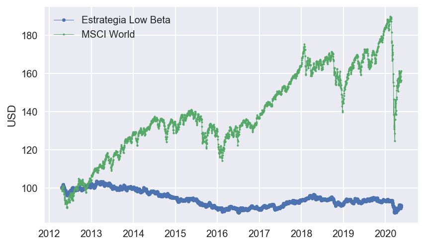

```python
fig, ax = plt.subplots()
ax.plot(assets_df['Low_Beta_Ix'],
marker='.', linestyle='-', linewidth=0.5, label='Estrategia Low Beta')
ax.plot(index_df['MXWO_Ix'],
marker='o', markersize=2, linestyle='-',linewidth=0.5, label='MSCI World')
ax.set_ylabel('USD')
ax.legend();
```

### Estrategia Risk Premia Size

```python
longWeight = 1
shortWeight = -1
index_df[['MXWO','MXWOSC']].head(10).style.background_gradient(cmap='YlGnBu')
```

|  | MXWO | MXWOSC |
| --- | --- | --- |
| 2012-04-18 00:00:00 | 1283.87 | 234.16 |
| 2012-04-19 00:00:00 | 1277.72 | 233.23 |
| 2012-04-20 00:00:00 | 1281.71 | 234.13 |
| 2012-04-23 00:00:00 | 1264.21 | 230.65 |
| 2012-04-24 00:00:00 | 1271.8 | 231.67 |
| 2012-04-25 00:00:00 | 1285.52 | 234.92 |
| 2012-04-26 00:00:00 | 1293.43 | 236.77 |
| 2012-04-27 00:00:00 | 1298.71 | 238.44 |
| 2012-04-30 00:00:00 | 1293.99 | 237.27 |
| 2012-05-01 00:00:00 | 1296.98 | 237.42 |

```python
val = []
val.append(100)
for i in range(1,index_df.shape[0]):
    val.append(val[i-1]*(1+shortWeight*index_df['MXWO_Return'].iloc[i]+longWeight*index_df['MXWOSC_Return'].iloc[i]))
assets_df['Size_Ix'] = val
```

```python
assets_df['Size']=assets_df['Size_Ix'].pct_change()
assets_df['Size'].fillna(0, inplace=True)
assets_df[['Size','Size_Ix']].head().style.background_gradient(cmap='YlGnBu')
```

|  | Size | Size_Ix |
| --- | --- | --- |
| 2012-04-18 00:00:00 | 0 | 100 |
| 2012-04-19 00:00:00 | 0.000818561 | 100.082 |
| 2012-04-20 00:00:00 | 0.000736102 | 100.156 |
| 2012-04-23 00:00:00 | -0.0012099 | 100.034 |
| 2012-04-24 00:00:00 | -0.00158146 | 99.8761 |

[figure not shown]

```python
fig, ax = plt.subplots()
ax.plot(assets_df['Size_Ix'],
marker='.', linestyle='-', linewidth=0.5, label='Estrategia Low Beta')
ax.plot(index_df['MXWO_Ix'],
marker='o', markersize=2, linestyle='-',linewidth=0.5, label='MSCI World')
ax.set_ylabel('USD')
ax.legend();
```

## Resumen de Activos

```python
def risk_contribution(w,cov):
    """
    Compute the contributions to risk of the constituents of a portfolio, given a set of portfolio weights and a covariance matrix
    """
    total_portfolio_var = erk.portfolio_vol(w,cov)**2
    # Marginal contribution of each constituent
    marginal_contrib = cov@w
    risk_contrib = np.multiply(marginal_contrib,w.T)/total_portfolio_var
    return risk_contrib

def to_percent(x):
    try: f_string = '{:.2%}'.format(x)
    except: f_string = x
    return f_string

def to_decimal(x):
    try:
        if x >= 100:
            f_string = '{0:,.0f}'.format(x)
        elif x >= 10:
            f_string = '{0:,.1f}'.format(x)
        else:
            f_string = '{0:,.2f}'.format(x)

    except: f_string = x
    return f_string

def annual_volatility(df_single_returns):
    """
    Determines the annual volatility of a strategy.

    Parameters
    ----------
    df_single_returns : pd.Series or np.ndarray
        Periodic returns of the strategy, noncumulative.

    Returns
    -------
    float, np.ndarray
        Annual volatility.
    """

    if len(df_single_returns) < 2:
        return np.nan

    std = df_single_returns.std(ddof=1)

    volatility = std * (252 ** (1.0 / 2))

    return volatility.apply(to_percent)#.astype(np.float)

def var_pct(df_single_returns):
    """
    Determines the annual var of a strategy.



    Parameters
    ----------
    df_single_returns : pd.Series or np.ndarray
        Periodic returns of the strategy, noncumulative.



    Returns
    -------
    float, np.ndarray
        Annual var (%).
    """



    if len(df_single_returns) < 2:
        return np.nan



    std = df_single_returns.std(ddof=1)
    vol = std * (252 ** (1.0 / 2))
    t=252
    ci=0.95


    var =  vol*scs.norm.cdf(scs.norm.ppf(1-ci))/np.sqrt(t) #scs.norm.ppf(1-ci, mean, vol) * np.sqrt(t)
    return var.astype(np.float)

def max_drawdown(df_returns):
    max_dd = (np.cumprod(1+df_returns)/np.maximum.accumulate(np.cumprod(1+df_returns))-1).min()
    return max_dd

def cal_max_dd(df_single_return):
    """
    Determines the maximum drawdown of a strategy.

    Parameters
    ----------
    df_single_return :
        Daily returns of the strategy, noncumulative.

    Returns
    ----------
    float
        Maximum drawdown.
    """
    if len(df_single_return) < 1:
        return np.nan

    df_perform_equity_curve = (1. + df_single_return).cumprod()
    df_perform_cum_max = df_perform_equity_curve.cummax()
    # drawdown series
    df_perform_drawdown = df_perform_equity_curve / df_perform_cum_max - 1
    max_dd = df_perform_drawdown.min()
    return max_dd

def annual_return(df_single_return, period):
    """Determines the mean annual growth rate of returns.

    Parameters
    ----------
    df_single_return : pd.Series or np.ndarray
        Periodic returns of the strategy, noncumulative.
    period : str, optional
        Defines the periodicity of the 'returns' data for purposes of
        annualizing. Value ignored if `annualization` parameter is specified.
        Defaults are:
            'monthly':12
            'weekly': 52
            'daily': 252

    Returns
    -------
    float
    """

    if len(df_single_return) < 1:
        return np.nan

    num_years = float(len(df_single_return)) / period

    # Pass array to ensure index -1 looks up successfully.
    df_cum = (df_single_return + 1).cumprod(axis=0) - 1
    f_annual_return = (1. + df_cum.iloc[-1,:]) ** (1. / num_years) - 1

    return f_annual_return.apply(to_percent)

def linreg(x,y):
    # We add a constant so that we can also fit an intercept (alpha) to the model
    # This just adds a column of 1s to our data
    x = sm.add_constant(x)
    model = regression.linear_model.OLS(y,x).fit()
    # Remove the constant now that we're done
    x = x[:, 1]
    return model.params[0], model.params[1]

def to_summary(df_returns, df_y=index_df,start='2012-04-19',col_y='MXWO_Return'):

    # Daily return calcs
    df_summary = pd.DataFrame(columns=df_returns.columns)
    df_summary.loc['Summary Stats:'] = ''
    MOIC = np.prod(1+df_returns)
    CAGR = MOIC**(periodicity/len(df_returns))-1
    df_summary.loc['Annualized Return'] = annual_return(df_returns, 252)
    df_summary.loc['Sharpe'] = CAGR/(np.std(df_returns)*np.sqrt(periodicity))
    df_summary.loc['Volatility'] = annual_volatility(df_returns)
    df_summary.loc['VaR'] = var_pct(df_returns).apply(to_percent)

    df_summary.loc['Sortino'] = CAGR/(np.std(np.clip(df_returns, a_max=0, a_min=None))*np.sqrt(periodicity))
    df_summary.loc['Max Drawdown'] = cal_max_dd(df_returns).apply(to_percent)
    #Alpha y Beta
    Y=df_y.loc[start:,col_y].values
    for col in df_returns.columns:
        X=df_returns.loc[start:,col]#.values
        #alpha, beta = linreg(X,Y)
        #df_summary.loc['Alpha',col]=to_percent(alpha)
        df_summary.loc['Beta',col]=to_percent(np.cov(Y,X)[0][1]/np.var(Y))
        #to_percent(beta)

    df_summary = df_summary.applymap(to_decimal)

    # Monthly return calcs
    df_summary.loc['Monthly Perf. Metrics:'] = ''
    df_months = pd.DataFrame(columns=df_returns.columns)
    df_returnsM = (1+df_returns).resample('M').prod()-1
    MOIC_M = np.prod(1+df_returnsM)
    CAGR_M = MOIC_M**(12/len(df_returnsM))-1
    df_months.loc['Sharpe'] = CAGR_M/(np.std(df_returnsM)*np.sqrt(12))
    df_months.loc['Sortino'] = CAGR_M/(np.std(np.clip(df_returnsM, a_max=0, a_min=None))*np.sqrt(12))

    if len(df_returnsM) >= 36: df_months.loc['Calmar'] = -(np.prod(1+df_returnsM.iloc[-12*3:])**(1/3)-1)\
                                                         / max_drawdown(df_returnsM.iloc[-12*3:])

    df_months = df_months.applymap(to_decimal)
    df_summary = df_summary.append(df_months)

    # Annuals
    df_summary.loc['Annual Returns:'] = ''
    df_annuals = df_returns.groupby(df_returns.index.year).apply(lambda x: np.prod(1+x)-1).applymap(to_percent)
    df_summary = df_summary.append(df_annuals)

    # Drawdowns
    df_summary.loc['Annual Max DD:'] = ''
    df_maxdd = df_returns.groupby(df_returns.index.year).apply(cal_max_dd).applymap(to_percent)
    df_summary = df_summary.append(df_maxdd)
    return df_summary
```

```python
returns = assets_df[['Value', 'Momentum', 'Quality', 'Low Beta','Size']]
returns.head().style.background_gradient(cmap='YlGnBu')
```

|  | Value | Momentum | Quality | Low Beta | Size |
| --- | --- | --- | --- | --- | --- |
| 2012-04-18 00:00:00 | 0 | 0 | 0 | 0 | 0 |
| 2012-04-19 00:00:00 | 0.0127191 | 0.00765891 | 0.00792395 | 0.00425905 | 0.000818561 |
| 2012-04-20 00:00:00 | 0.00415702 | 0.0025338 | -0.000671276 | -0.000796017 | 0.000736102 |
| 2012-04-23 00:00:00 | 0.00847159 | 0.000571509 | 0.0140536 | -0.000735095 | -0.0012099 |
| 2012-04-24 00:00:00 | -0.000641423 | -0.00673107 | -0.0131587 | 0.00235314 | -0.00158146 |

```python
lookback = 21*6
corr_lookback = 21*24
periodicity = 252
num_portfolios = 25000
risk_free_rate = 0.0178
returns.fillna(0, inplace=True)
mean_returns = returns.mean()
```

```python
to_summary(returns)
```

|  | Value | Momentum | Quality | Low Beta | Size |
| --- | --- | --- | --- | --- | --- |
| Summary Stats: |  |  |  |  |  |
| Annualized Return | 2.57% | 14.12% | 10.27% | -1.13% | -0.77% |
| Sharpe | 0.33 | 1.42 | 0.92 | -0.22 | -0.16 |
| Volatility | 7.83% | 9.94% | 11.14% | 5.05% | 4.80% |
| VaR | 0.02% | 0.03% | 0.04% | 0.02% | 0.02% |
| Sortino | 0.56 | 2.46 | 1.60 | -0.37 | -0.25 |
| Max Drawdown | -18.52% | -13.70% | -20.21% | -15.89% | -23.19% |
| Beta | -23.91% | -19.59% | -30.65% | 13.54% | 0.65% |
| Monthly Perf. Metrics: |  |  |  |  |  |
| Sharpe | 0.38 | 1.21 | 0.83 | -0.26 | -0.14 |
| Sortino | 0.80 | 3.81 | 2.54 | -0.37 | -0.20 |
| Calmar | 1.88 | 11.0 | 6.18 | 0.09 | -0.23 |
| Annual Returns: |  |  |  |  |  |
| 2012 | 6.57% | 2.88% | -2.04% | 1.23% | 0.25% |
| 2013 | -10.24% | -5.15% | -8.48% | -0.90% | 5.07% |
| 2014 | -0.29% | 16.98% | 13.43% | -5.43% | -2.37% |
| 2015 | 1.36% | 7.97% | 10.47% | -5.62% | 0.78% |
| 2016 | -3.61% | -6.14% | -3.56% | -0.90% | 5.43% |
| 2017 | 3.01% | 10.15% | 9.35% | 5.20% | 0.71% |
| 2018 | 6.56% | 13.44% | 18.92% | -1.78% | -5.40% |
| 2019 | 7.78% | 30.72% | 20.14% | 1.95% | -0.87% |
| 2020 | 12.18% | 59.90% | 33.92% | -2.70% | -9.17% |
| Annual Max DD: |  |  |  |  |  |
| 2012 | -5.63% | -5.89% | -12.61% | -5.59% | -3.95% |
| 2013 | -13.94% | -11.06% | -11.02% | -4.76% | -2.66% |
| 2014 | -5.88% | -3.06% | -2.87% | -5.67% | -8.05% |
| 2015 | -6.99% | -6.66% | -8.10% | -6.22% | -3.98% |
| 2016 | -14.79% | -12.15% | -18.31% | -3.81% | -2.76% |
| 2017 | -4.27% | -4.12% | -3.63% | -3.25% | -2.46% |
| 2018 | -5.95% | -5.96% | -3.30% | -6.35% | -8.86% |
| 2019 | -8.28% | -4.41% | -6.75% | -2.65% | -5.75% |
| 2020 | -8.68% | -13.70% | -10.54% | -7.32% | -15.39% |

## Rendimiento de la Cartera

```python
data=data_df[['Name','Currency','Sector', 'Country']]
```

```python
#Pesos por modelo
model_weights = [.42,.12,.22,.12,.12]
#Value
data= data.join(val_df[['EBITDA_EV_12M','Total']], how='inner')
data.drop(['EBITDA_EV_12M'], axis=1, inplace=True)
data.columns=['Name','Currency','Sector', 'Country','Value']
```

```python
#Momentum
data= data.join(mom_df[['Rentab 1Y']], how='inner')
data.columns=['Name','Currency','Sector','Country','Value','Momentum']
```

```python
#Quality
data= data.join(qual_df[['NET_OPERATING_ASSETS','Total']], how='inner')
data.drop(['NET_OPERATING_ASSETS'], axis=1, inplace=True)
data.columns=['Name','Currency','Sector','Country','Value','Momentum','Quality']
```

```python
#Quality
data= data.join(beta_df[['EQY_BETA']], how='inner')
data.columns=['Name','Currency','Sector','Country','Value','Momentum','Quality','Low Beta']
```

```python
cols =['Value', 'Momentum','Quality','Low Beta','Size']
w_model=dict(zip(cols,model_weights))
w_model
```

```
{'Value': 0.42,
 'Momentum': 0.12,
 'Quality': 0.22,
 'Low Beta': 0.12,
 'Size': 0.12}
```

```python
df_portfolio=pd.DataFrame()
df_portfolio['Rentabilidad']=annual_return(returns, 252).apply(lambda x: float(x[:-1])/100)
df_portfolio['Volatilidad'] = annual_volatility(returns).apply(lambda x: float(x[:-1])/100)
#Beta
start='2012-04-19'
col_y='MXWO_Return'
Y=index_df.loc[start:,col_y].values
for col in returns.columns:
    X=returns.loc[start:,col].values
    alpha, beta = linreg(X,Y)
    df_portfolio.loc[col,'Alfa']=alpha
    df_portfolio.loc[col,'Beta']=beta
df_portfolio['Peso']=model_weights
df_portfolio.head()
```

|  | Rentabilidad | Volatilidad | Alfa | Beta | Peso |
| --- | --- | --- | --- | --- | --- |
| Value | 0.0257 | 0.0783 | 0.000351 | -0.760121 | 0.42 |
| Momentum | 0.1412 | 0.0994 | 0.000476 | -0.386459 | 0.12 |
| Quality | 0.1027 | 0.1114 | 0.000464 | -0.481587 | 0.22 |
| Low Beta | -0.0113 | 0.0505 | 0.000307 | 1.034307 | 0.12 |
| Size | -0.0077 | 0.0480 | 0.000267 | 0.055239 | 0.12 |

### Matriz de Correlación

```python
returns.corr().style.background_gradient(cmap='YlGnBu')
```

|  | Value | Momentum | Quality | Low Beta | Size |
| --- | --- | --- | --- | --- | --- |
| Value | 1 | 0.618022 | 0.716801 | -0.269941 | -0.220279 |
| Momentum | 0.618022 | 1 | 0.820311 | -0.128497 | -0.246811 |
| Quality | 0.716801 | 0.820311 | 1 | -0.20972 | -0.21249 |
| Low Beta | -0.269941 | -0.128497 | -0.20972 | 1 | 0.122968 |
| Size | -0.220279 | -0.246811 | -0.21249 | 0.122968 | 1 |

### Matriz de Covarianza

```python
covMatrix=returns.cov()
covMatrix.style.background_gradient(cmap='YlGnBu')
```

|  | Value | Momentum | Quality | Low Beta | Size |
| --- | --- | --- | --- | --- | --- |
| Value | 2.43417e-05 | 1.90944e-05 | 2.48167e-05 | -4.23934e-06 | -3.2839e-06 |
| Momentum | 1.90944e-05 | 3.92151e-05 | 3.60475e-05 | -2.56137e-06 | -4.67017e-06 |
| Quality | 2.48167e-05 | 3.60475e-05 | 4.92424e-05 | -4.6845e-06 | -4.50557e-06 |
| Low Beta | -4.23934e-06 | -2.56137e-06 | -4.6845e-06 | 1.01323e-05 | 1.18273e-06 |
| Size | -3.2839e-06 | -4.67017e-06 | -4.50557e-06 | 1.18273e-06 | 9.13026e-06 |

```python
returns['Portfolio'] = returns.assign(**w_model).mul(returns).sum(1)
returns.head().style.background_gradient(cmap='YlGnBu')
```

|  | Value | Momentum | Quality | Low Beta | Size | Portfolio |
| --- | --- | --- | --- | --- | --- | --- |
| 2012-04-18 00:00:00 | 0 | 0 | 0 | 0 | 0 | 0 |
| 2012-04-19 00:00:00 | 0.0127191 | 0.00765891 | 0.00792395 | 0.00425905 | 0.000818561 | 0.00861367 |
| 2012-04-20 00:00:00 | 0.00415702 | 0.0025338 | -0.000671276 | -0.000796017 | 0.000736102 | 0.00189513 |
| 2012-04-23 00:00:00 | 0.00847159 | 0.000571509 | 0.0140536 | -0.000735095 | -0.0012099 | 0.00648504 |
| 2012-04-24 00:00:00 | -0.000641423 | -0.00673107 | -0.0131587 | 0.00235314 | -0.00158146 | -0.00387944 |

```python
val = []
val.append(100)
for i in range(1,returns.shape[0]):
    val.append(val[i-1]*(1+returns['Portfolio'].iloc[i]))
returns['Portfolio_Ix'] = val
```

```python
returns.head()
```

|  | Value | Momentum | Quality | Low Beta | Size | Portfolio | Portfolio_Ix |
| --- | --- | --- | --- | --- | --- | --- | --- |
| 2012-04-18 | 0.000000 | 0.000000 | 0.000000 | 0.000000 | 0.000000 | 0.000000 | 100.000000 |
| 2012-04-19 | 0.012719 | 0.007659 | 0.007924 | 0.004259 | 0.000819 | 0.008614 | 100.861367 |
| 2012-04-20 | 0.004157 | 0.002534 | -0.000671 | -0.000796 | 0.000736 | 0.001895 | 101.052513 |
| 2012-04-23 | 0.008472 | 0.000572 | 0.014054 | -0.000735 | -0.001210 | 0.006485 | 101.707843 |
| 2012-04-24 | -0.000641 | -0.006731 | -0.013159 | 0.002353 | -0.001581 | -0.003879 | 101.313274 |

```python
to_summary(returns[['Portfolio']])
```

|  | Portfolio |
| --- | --- |
| Summary Stats: |  |
| Annualized Return | 4.86% |
| Sharpe | 0.80 |
| Volatility | 6.05% |
| VaR | 0.02% |
| Sortino | 1.38 |
| Max Drawdown | -11.36% |
| Beta | -17.43% |
| Monthly Perf. Metrics: |  |
| Sharpe | 0.84 |
| Sortino | 2.08 |
| Calmar | 5.17 |
| Annual Returns: |  |
| 2012 | 2.90% |
| 2013 | -6.32% |
| 2014 | 3.74% |
| 2015 | 3.25% |
| 2016 | -2.34% |
| 2017 | 5.28% |
| 2018 | 7.50% |
| 2019 | 11.25% |
| 2020 | 17.15% |
| Annual Max DD: |  |
| 2012 | -4.76% |
| 2013 | -8.90% |
| 2014 | -2.97% |
| 2015 | -4.91% |
| 2016 | -11.02% |
| 2017 | -2.32% |
| 2018 | -2.30% |
| 2019 | -4.43% |
| 2020 | -6.81% |

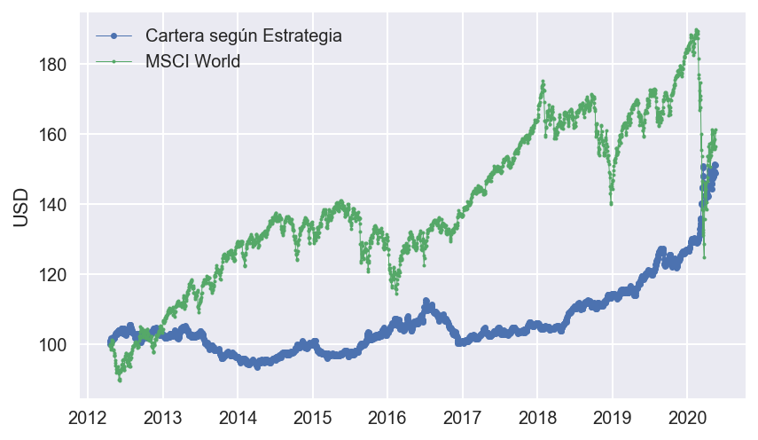

```python
fig, ax = plt.subplots()
ax.plot(returns['Portfolio_Ix'],
        marker='.', linestyle='-', linewidth=0.5, label='Cartera según Estrategia')
ax.plot(index_df['MXWO_Ix'],
        marker='o', markersize=2, linestyle='-',linewidth=0.5, label='MSCI World')
ax.set_ylabel('USD')
ax.legend();
```

## Conclusiones

Como conclusión, hemos realizado la estrategia de ARP (Alternative Risk Premia) con distintos criterios de riesgo. Las características de cada uno de ellos se pueden analizar en la tabla adjunta:

[output not shown]

# Bibliografía

- An Introduction to Alternative Risk Premia, Guillaume Monarcha.
- An Introduction to Alternative Risk Premia, Morgan Stanley[https://www.morganstanley.com/im/publication/insights/investment-insights/ii_anintroductiontoalternativeriskpremia_us.pdf]
- Análisis de Cartera y Riesgo: PORT, La Terminal Bloomberg [https://www.bloomberg.com/latam/producto/analisis-de-cartera-y-riesgo/]